# IODS course project

Kiira

# Introduction to Open Data Science - Course Project

# Longitudinal data analysis (week 6)

> *The last week of the course was about longitudinal data and linear mixed effect models*

In this exercise, two dataset are used. One dataset has brief psychiatric rating scale (BPRS) data from 40 males in baseline and weekly for 8 weeks. The other dataset has information of rats on 3 different diets, with observations of the weight for 9 weeks.

## Analysis of rat weight in different diets

The data has 16 rats in 3 different diets (groups) followed for total 11 timepoints, including the baseline measurement and two measurements in week 7. First, the data is read in and observed.

```r
#Reading the data in, changing variables to factors and observing the data
data <- read.delim("RATSL_data.txt", sep = " ")

data$ID <- as.factor(data$ID)
data$Group <- as.factor(data$Group)

glimpse(data)
```

```
## Rows: 176
## Columns: 5
## $ ID     <fct> 1, 2, 3, 4, 5, 6, 7, 8, 9, 10, 11, 12, 13, 14, 15, 16, 1, 2,...
## $ Group  <fct> 1, 1, 1, 1, 1, 1, 1, 1, 2, 2, 2, 2, 3, 3, 3, 3, 1, 1, 1, 1, ...
## $ WD     <chr> "WD1", "WD1", "WD1", "WD1", "WD1", "WD1", "WD1", "WD1", "WD1...
## $ Weight <int> 240, 225, 245, 260, 255, 260, 275, 245, 410, 405, 445, 555, ...
## $ Time   <int> 1, 1, 1, 1, 1, 1, 1, 1, 1, 1, 1, 1, 1, 1, 1, 1, 8, 8, 8, 8, ...
```

The data is visualized and it is noted that groups 2 and 3 differ in weight already at the start of the study.

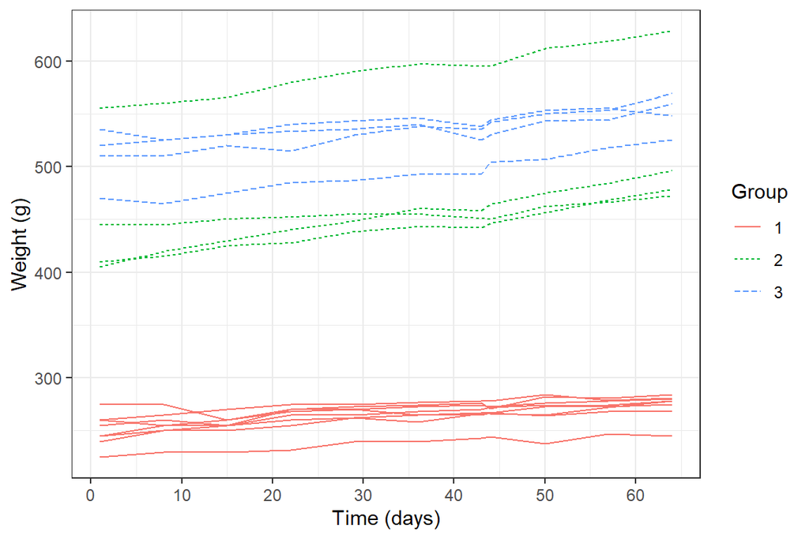

```r
#Plotting the rat data
ggplot(data, aes(x = Time, y = Weight, group = ID, color = Group)) +
  geom_line(aes(linetype = Group))+
  scale_x_continuous(name = "Time (days)", breaks = seq(0, 60, 10))+
  scale_y_continuous(name = "Weight (g)")+
  theme(legend.position = "top")+
  theme_bw()
```

From the graph above, it is also noticed, that one of the group 2 rats is much heavier than any rat in groups 2 or 3, already at baseline.

This can also be seen from the summary below, where in group 2, the max weight is higher than mean of either groups 2 or 3.

```r
#Calculating max and median weights for rats in the different groups
data %>%
  group_by(Group) %>%
  summarise(max(Weight), mean(Weight))
```

```
## # A tibble: 3 x 3
##   Group `max(Weight)` `mean(Weight)`
##   <fct>         <int>          <dbl>
## 1 1               284           264.
## 2 2               628           485.
## 3 3               569           526.
```

Therefore, the outlier rat is fetched and removed from the data.

```r
#Observing which is the heaviest rat (in group 2) and excluding it from the data
a <-data %>%
  arrange(desc(Weight))
head(a) #rat ID 12
```

```
##     ID Group   WD Weight Time
## 172 12     2 WD64    628   64
## 156 12     2 WD57    618   57
## 140 12     2 WD50    612   50
## 92  12     2 WD36    597   36
## 108 12     2 WD43    595   43
## 124 12     2 WD44    595   44
```

```r
data2 <- data %>%
  filter(ID != 12)
```

Now, group means and standard errors are calculated in every group, per timepoint.

```r
#Then lets plot the group means and standard errors of the groups
n = 11 # Different times
data2 <- data2 %>%
  group_by(Group, Time) %>%
  mutate(mean = mean(Weight), se= sd(Weight)/sqrt(n))
glimpse(data2)
```

```
## Rows: 165
## Columns: 7
## Groups: Group, Time [33]
## $ ID     <fct> 1, 2, 3, 4, 5, 6, 7, 8, 9, 10, 11, 13, 14, 15, 16, 1, 2, 3, ...
## $ Group  <fct> 1, 1, 1, 1, 1, 1, 1, 1, 2, 2, 2, 3, 3, 3, 3, 1, 1, 1, 1, 1, ...
## $ WD     <chr> "WD1", "WD1", "WD1", "WD1", "WD1", "WD1", "WD1", "WD1", "WD1...
## $ Weight <int> 240, 225, 245, 260, 255, 260, 275, 245, 410, 405, 445, 470, ...
## $ Time   <int> 1, 1, 1, 1, 1, 1, 1, 1, 1, 1, 1, 1, 1, 1, 1, 8, 8, 8, 8, 8, ...
## $ mean   <dbl> 250.6250, 250.6250, 250.6250, 250.6250, 250.6250, 250.6250, ...
## $ se     <dbl> 4.589478, 4.589478, 4.589478, 4.589478, 4.589478, 4.589478, ...
```

The data is visualized by the means and standard errors of the different groups

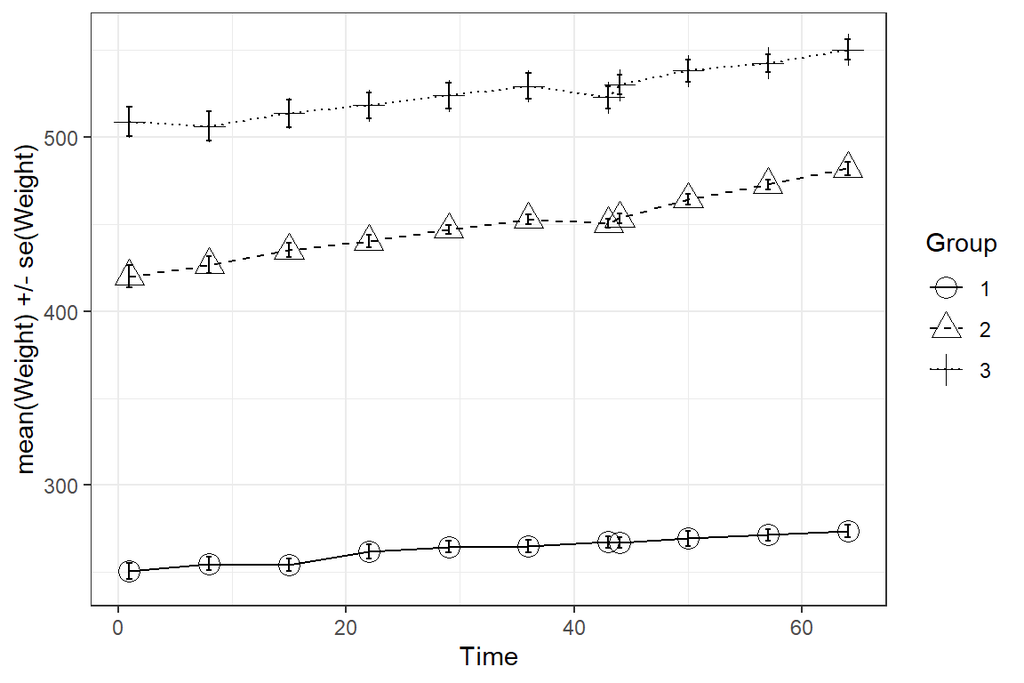

```r
#Plotting mean  and standard error of the groups per timepoint
ggplot(data2, aes(x = Time, y = mean, linetype = Group, shape = Group)) +
  geom_line() +
  scale_linetype_manual(values = c(1,2,3)) +
  geom_point(size=4) +
  scale_shape_manual(values = c(1,2,3)) +
  geom_errorbar(aes(ymin=mean-se, ymax=mean+se, linetype="1"), width=0.5) +
  theme(legend.position = c(0.8,0.8)) +
  scale_y_continuous(name = "mean(Weight) +/- se(Weight)")+
  theme_bw()
```

Now, only baseline weight and weight in the last week are kept in the data.

```r
g <- data2 %>%
 select(Weight, Time, Group) %>%
  filter(Time ==1 | Time == 64)
```

The weight in each group in week 0 and in the last week are visualized, to see whether the weight of the rats have changed due to the diet. Nothced boxplot is used, which includes the confidence interval for each set.

[output not shown]

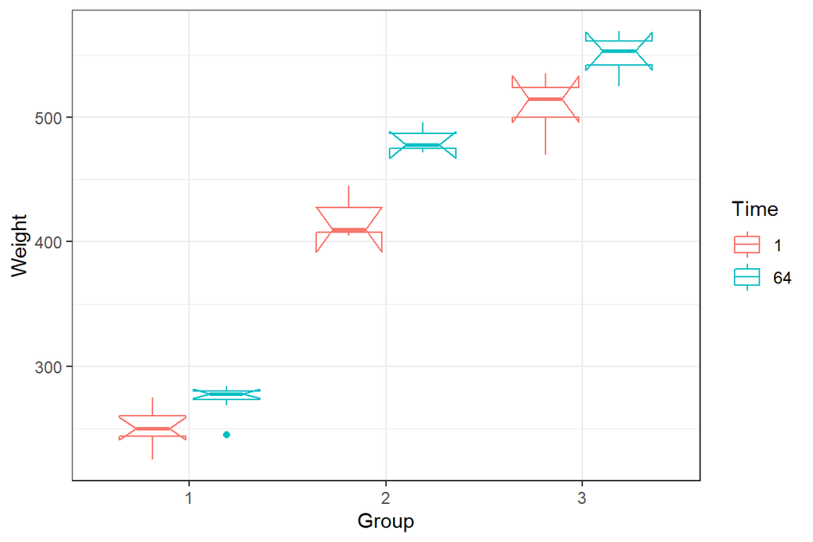

```r
g$Time <- as.factor(g$Time)
ggplot(g, aes(x= Group, y= Weight, color = Time)) + geom_boxplot(notch = T)+
  theme_bw()
```

It is noticed from the plot, that group 2 is at least differing between the timepoints, but let’s calculate p-values for the groups 1 and 3. First, the data is divided to sets per the group.

```r
g1 <- data2 %>%
 select(Weight, Time, Group) %>%
  filter(Group ==1, Time ==1 | Time == 64)

g3 <- data2 %>%
 select(Weight, Time, Group) %>%
  filter(Group ==3, Time ==1 | Time == 64)
```

Then, hypothesis testing is done with t-test, measuring whether the means of the weight differ in start and end of the study.

```r
# Hypothesis testing, testing whether means in start and end of the study differ between group 1
t.test(Weight ~Time, data = g1)
```

```
##
##  Welch Two Sample t-test
##
## data:  Weight by Time
## t = -3.3271, df = 13.467, p-value = 0.005226
## alternative hypothesis: true difference in means is not equal to 0
## 95 percent confidence interval:
##  -38.088042  -8.161958
## sample estimates:
##  mean in group 1 mean in group 64
##          250.625          273.750
```

```r
# and in group 3
t.test(Weight ~Time, data = g3)
```

```
##
##  Welch Two Sample t-test
##
## data:  Weight by Time
## t = -2.4693, df = 5.2837, p-value = 0.05396
## alternative hypothesis: true difference in means is not equal to 0
## 95 percent confidence interval:
##  -84.014005   1.014005
## sample estimates:
##  mean in group 1 mean in group 64
##           508.75           550.25
```

So, it looks like the diet can alter the weight in groups 1 and 2, but not in group 3. However, the difference in group 1 could be even higher if the one outlier would be removed.

## Second analysis: psychiatric intervention

```r
#Reading the data in, changing variables to factors and observing the data
datab <- read.delim("BPRSL_data.txt", sep = " ")

datab$treatment <- as.factor(datab$treatment)
datab$subject <- as.factor(datab$subject)
glimpse(datab)
```

```
## Rows: 360
## Columns: 5
## $ treatment <fct> 1, 1, 1, 1, 1, 1, 1, 1, 1, 1, 1, 1, 1, 1, 1, 1, 1, 1, 1, ...
## $ subject   <fct> 1, 2, 3, 4, 5, 6, 7, 8, 9, 10, 11, 12, 13, 14, 15, 16, 17...
## $ weeks     <chr> "week0", "week0", "week0", "week0", "week0", "week0", "we...
## $ bprs      <int> 42, 58, 54, 55, 72, 48, 71, 30, 41, 57, 30, 55, 36, 38, 6...
## $ week      <int> 0, 0, 0, 0, 0, 0, 0, 0, 0, 0, 0, 0, 0, 0, 0, 0, 0, 0, 0, ...
```

The data is visualized, where each individual is represented in its own color and different treatments with differently shaped marks.

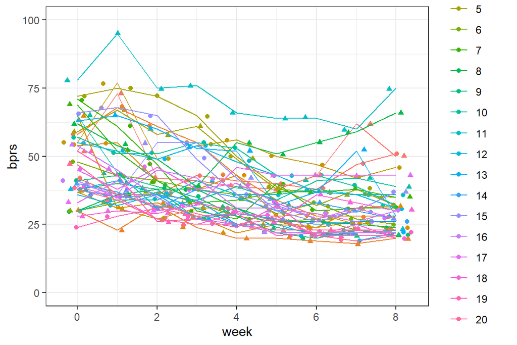

```r
ggplot(datab, aes(x = week, y = bprs, color = subject, shape = treatment)) +
  geom_point(position = "jitter")+
  geom_line()+
  theme(legend.position = "top")+
  scale_y_continuous(limits = c(0, 100))+
  theme_bw()
```

Then, regression model for the data is calculated, to see whether the treatment and time can explain variation in the brief psychitric rating scale (bprs). According to the model, treatment is not significant explanatory factor in the model, which suggests that the treatment might not have an effect to the psychiatric condition, when measured with bprs. The time again has significant effect to the score.

```r
BPRS_reg <- lm(bprs ~treatment + week, data = datab)
summary(BPRS_reg)
```

```
##
## Call:
## lm(formula = bprs ~ treatment + week, data = datab)
##
## Residuals:
##     Min      1Q  Median      3Q     Max
## -22.454  -8.965  -3.196   7.002  50.244
##
## Coefficients:
##             Estimate Std. Error t value Pr(>|t|)
## (Intercept)  46.4539     1.3670  33.982   <2e-16 ***
## treatment2    0.5722     1.3034   0.439    0.661
## week         -2.2704     0.2524  -8.995   <2e-16 ***
## ---
## Signif. codes:  0 '***' 0.001 '**' 0.01 '*' 0.05 '.' 0.1 ' ' 1
##
## Residual standard error: 12.37 on 357 degrees of freedom
## Multiple R-squared:  0.1851, Adjusted R-squared:  0.1806
## F-statistic: 40.55 on 2 and 357 DF,  p-value: < 2.2e-16
```

Random intercept model is also tested, to see whether including the subject information as random effect alters the former linear model. In the model, bprs is allowed to vary in each subject.

```r
BPRS_ref <- lmer(bprs ~ week + treatment + (1 | subject), data = datab, REML = FALSE)
summary(BPRS_ref)
```

```
## Linear mixed model fit by maximum likelihood  ['lmerMod']
## Formula: bprs ~ week + treatment + (1 | subject)
##    Data: datab
##
##      AIC      BIC   logLik deviance df.resid
##   2748.7   2768.1  -1369.4   2738.7      355
##
## Scaled residuals:
##     Min      1Q  Median      3Q     Max
## -3.0481 -0.6749 -0.1361  0.4813  3.4855
##
## Random effects:
##  Groups   Name        Variance Std.Dev.
##  subject  (Intercept)  47.41    6.885
##  Residual             104.21   10.208
## Number of obs: 360, groups:  subject, 20
##
## Fixed effects:
##             Estimate Std. Error t value
## (Intercept)  46.4539     1.9090  24.334
## week         -2.2704     0.2084 -10.896
## treatment2    0.5722     1.0761   0.532
##
## Correlation of Fixed Effects:
##            (Intr) week
## week       -0.437
## treatment2 -0.282  0.000
```

Also, the effect of weekly change in subject is taken account in the following model

```r
BPRS_ref2 <- lmer(bprs ~ week + treatment + (week | subject), data = datab, REML = FALSE)
summary(BPRS_ref2)
```

```
## Linear mixed model fit by maximum likelihood  ['lmerMod']
## Formula: bprs ~ week + treatment + (week | subject)
##    Data: datab
##
##      AIC      BIC   logLik deviance df.resid
##   2745.4   2772.6  -1365.7   2731.4      353
##
## Scaled residuals:
##     Min      1Q  Median      3Q     Max
## -2.8919 -0.6194 -0.0691  0.5531  3.7976
##
## Random effects:
##  Groups   Name        Variance Std.Dev. Corr
##  subject  (Intercept) 64.8222  8.0512
##           week         0.9609  0.9802   -0.51
##  Residual             97.4305  9.8707
## Number of obs: 360, groups:  subject, 20
##
## Fixed effects:
##             Estimate Std. Error t value
## (Intercept)  46.4539     2.1052  22.066
## week         -2.2704     0.2977  -7.626
## treatment2    0.5722     1.0405   0.550
##
## Correlation of Fixed Effects:
##            (Intr) week
## week       -0.582
## treatment2 -0.247  0.000
```

The different models are then compared using analysis of variance (ANOVA)

```r
anova(BPRS_ref, BPRS_ref2)
```

```
## Data: datab
## Models:
## BPRS_ref: bprs ~ week + treatment + (1 | subject)
## BPRS_ref2: bprs ~ week + treatment + (week | subject)
##           npar    AIC    BIC  logLik deviance  Chisq Df Pr(>Chisq)
## BPRS_ref     5 2748.7 2768.1 -1369.4   2738.7
## BPRS_ref2    7 2745.4 2772.6 -1365.7   2731.4 7.2721  2    0.02636 *
## ---
## Signif. codes:  0 '***' 0.001 '**' 0.01 '*' 0.05 '.' 0.1 ' ' 1
```

There is significant difference in the P-value (Chi-squared test) in the two models, so lets use the latter, more advanced model.

Also, lets yet test one model which takes into account the weekly and inter-subject variability, and compare it to the later model

```r
BPRS_ref3 <- lmer(bprs ~ week + treatment + (week | subject) + (week | treatment), data = datab, REML = FALSE)
```

```
## boundary (singular) fit: see ?isSingular
```

```r
anova(BPRS_ref2, BPRS_ref3)
```

```
## Data: datab
## Models:
## BPRS_ref2: bprs ~ week + treatment + (week | subject)
## BPRS_ref3: bprs ~ week + treatment + (week | subject) + (week | treatment)
##           npar    AIC    BIC  logLik deviance  Chisq Df Pr(>Chisq)
## BPRS_ref2    7 2745.4 2772.6 -1365.7   2731.4
## BPRS_ref3   10 2750.9 2789.8 -1365.5   2730.9 0.5158  3     0.9154
```

The P-value is really big, so the fit of the model against the comparison model is not good.

Then, the model that takes into account weekly & inter-subject variability is used. Fitted values are calculated and added to the data

```r
Fitted <- fitted(BPRS_ref2)

datab <-datab %>%
mutate(Fitted = Fitted)
```

And then, the fitted values are plotted in the same manner as the original data

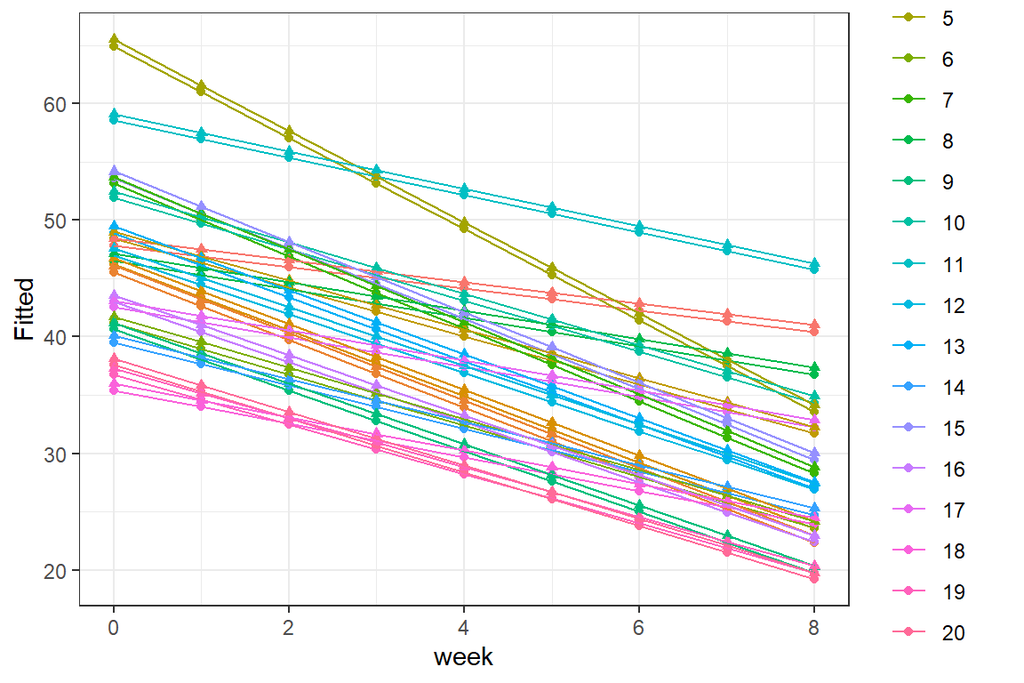

```r
ggplot(datab, aes(x = week, y = Fitted, shape = treatment, color = subject))+
  geom_point() +
  geom_line()+
  theme(legend.position = "top") +
  theme_bw()
```

Therefore, the brief psychiatric test scores decrease in all of the individuals throughout the time, regardless of the treatment. ***